# Chess Elo Prediction — v4

Predicting White and Black Elo ratings from chess game data using a multi-task neural network. The model combines hand-crafted board/clock features with optional sequence embeddings from a pre-trained autoencoder, and outputs a full probability distribution over rating ranges rather than a single number.

**Pipeline overview:**

1. Stream and filter games from a Lichess `.pgn.zst` database
2. Extract board features (python-chess replay) and clock features — both cached to disk
3. Optionally train a sequence autoencoder and cache its embeddings
4. Train a multi-task MLP (or MLP + AE) with KL-divergence loss against soft Gaussian targets
5. Evaluate on held-out test set and visualise results
6. Run inference on a single pasted PGN game

## Config

All settings in one place. The comments explain what each flag does and what to change for laptop vs GPU.

```
Device : cpu  |  AMP : False  |  CPU threads : 14
Sequential=False  |  AE=True  |  DistTarget=True
MAX_GAMES=2,000,000  |  BATCH=128  |  LR=0.0003  |  DROPOUT=0.3
Time control filter: None  |  Min plies: 12  |  Max seq len: 120
HPO enabled
```

## Data Loading

Stream-parse the compressed PGN file. We read line by line rather than loading everything into memory, which is important for multi-million game files.

[output not shown]

## Feature Extraction

Board features require replaying every game move-by-move with python-chess, which is slow. Both board and clock features are cached to disk — if the cache exists they load instantly.

```
Board features loaded from cache  (35 cols)
Clock features loaded from cache  (10 cols)
Full feature matrix: (534045, 69)
```

## Move Tokenisation

Each unique chess move (e.g. `e4`, `Nf3`, `O-O`) gets assigned an integer ID. This is needed for the sequence model and autoencoder.

```
Dropped 7,049 games shorter than 12 plies
Vocabulary size : 10,199
Games ready     : 526,996
```

## Soft Distribution Targets

Rather than treating Elo prediction as a regression to a single number, we model each player's strength as a Gaussian distribution centred on their rating (σ=200). This reflects the real game-to-game variance in how a player performs — a 1600-rated player sometimes plays like a 1400, sometimes like an 1800.

The model outputs a 40-bin probability distribution over the range 0–4000. The point estimate is the weighted mean of that distribution. Training uses KL-divergence between predicted and target distributions.

```
1600 Elo dist: peak at 1550,  recovered = 1600
```

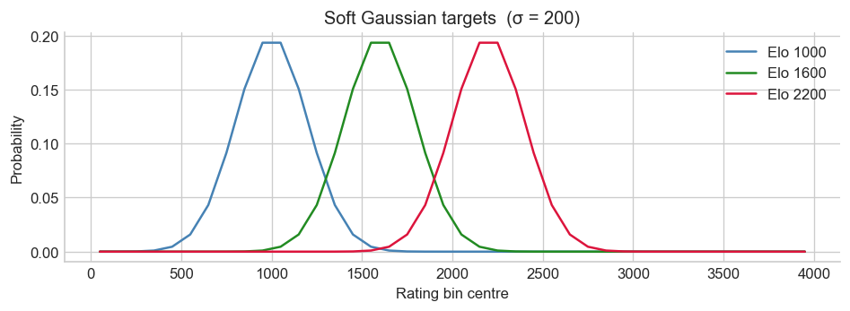

## Feature Selection, Train/Val/Test Split & Scaling

The split is stratified by Elo bracket so every rating range appears proportionally in all three sets. The scaler is fit on training data only — no information from val or test leaks into the scaling.

```
Static feature columns selected: 45
  [on ] game_structure      (3 cols)
  [on ] checks              (4 cols)
  [on ] captures            (5 cols)
  [on ] castling            (2 cols)
  [on ] style               (9 cols)
  [on ] engine_quality      (10 cols)
  [on ] clock               (10 cols)
  [on ] tc_meta             (2 cols)

Split — train: 421,596  val: 52,700  test: 52,700
Scaling done (StandardScaler fit on train only)
```

## Sequence Autoencoder

The autoencoder compresses each game's move sequence into a fixed-size vector (32 dimensions by default). It's trained once on a sample of games, then used to encode all games, and the resulting vectors are saved to disk. During main model training these cached vectors are used as extra static features, so we get sequence information without the cost of running an LSTM every training batch.

Architecture: BiLSTM encoder → 32-d bottleneck → LSTM decoder with teacher forcing.

```
AE embeddings loaded from cache: (526996, 32)
AE embeddings ready — 32 dims per game
```

## Dataset & DataLoaders

```
Building datasets...
  Built in 310s   total static dim = 77
Batches per epoch: 3,294
```

## Model

The model has two branches that get concatenated before prediction:

**Static branch:** MLP over board + clock features (+ AE embeddings if enabled). Uses LayerNorm and GELU activations which work well for tabular data.

**Sequence branch (optional):** Embedding → BiLSTM → soft attention pooling. Each move is represented as [embedding | normalised clock | turn flag].

**Output:** Two heads (White and Black), each predicting a softmax over 40 rating bins.

```
Model built — 1,354,481 trainable parameters
```

```
Running hyperparameter search — 20 trials on 50,000 games...
```

```
Best val loss: 0.9733
Best hyperparameters:
  lr              = 0.0008709611683297226
  dropout         = 0.21157933600922446
  hidden_dim      = 128
  embed_dim       = 64
  batch_size      = 64
  weight_decay    = 0.00012074484429484959
```

[output not shown]

[figure not shown]

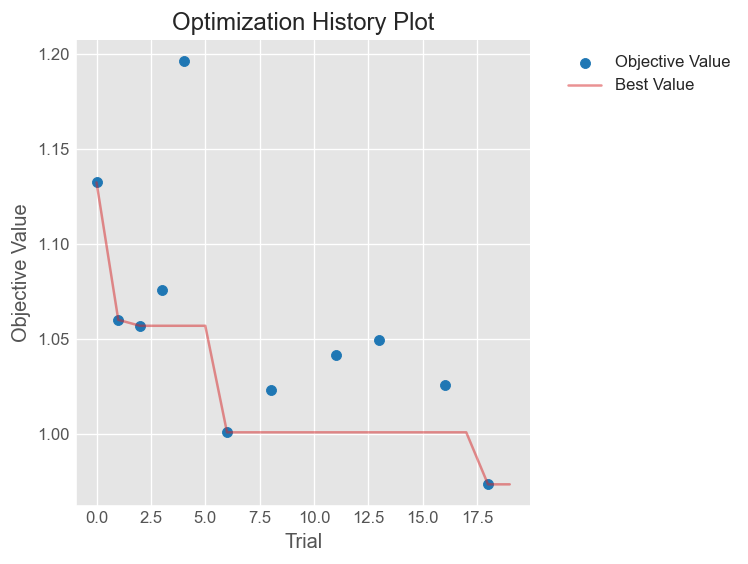

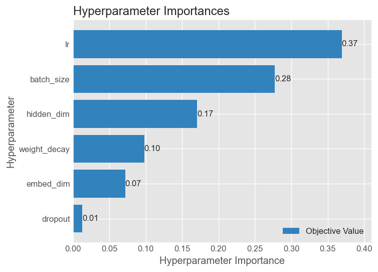

## Training

[output not shown]

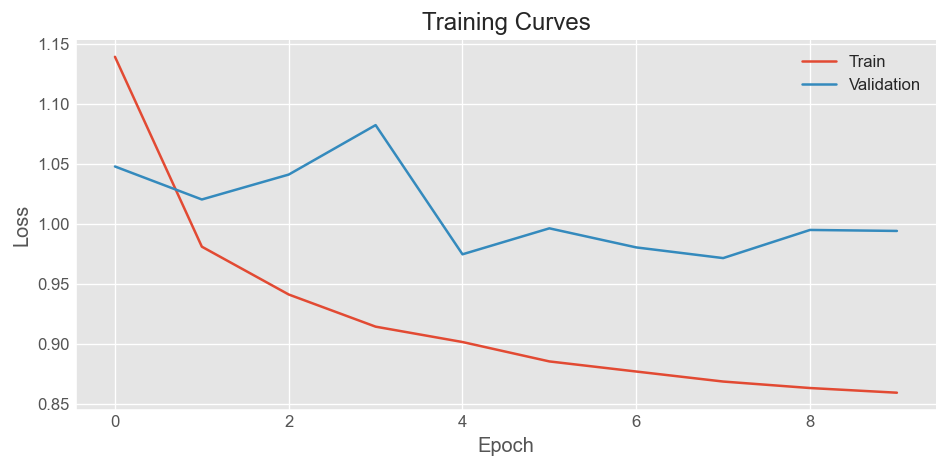

## Evaluation

```
Loaded checkpoint: chess_elo_v4_1e+06.pth
MAE    — White: 196.9  Black: 195.8  Combined: 196.3
Median — White: 162.4  Black: 162.0
Within 100 Elo: 32.4%
Within 200 Elo: 59.2%
Within 300 Elo: 78.0%
```

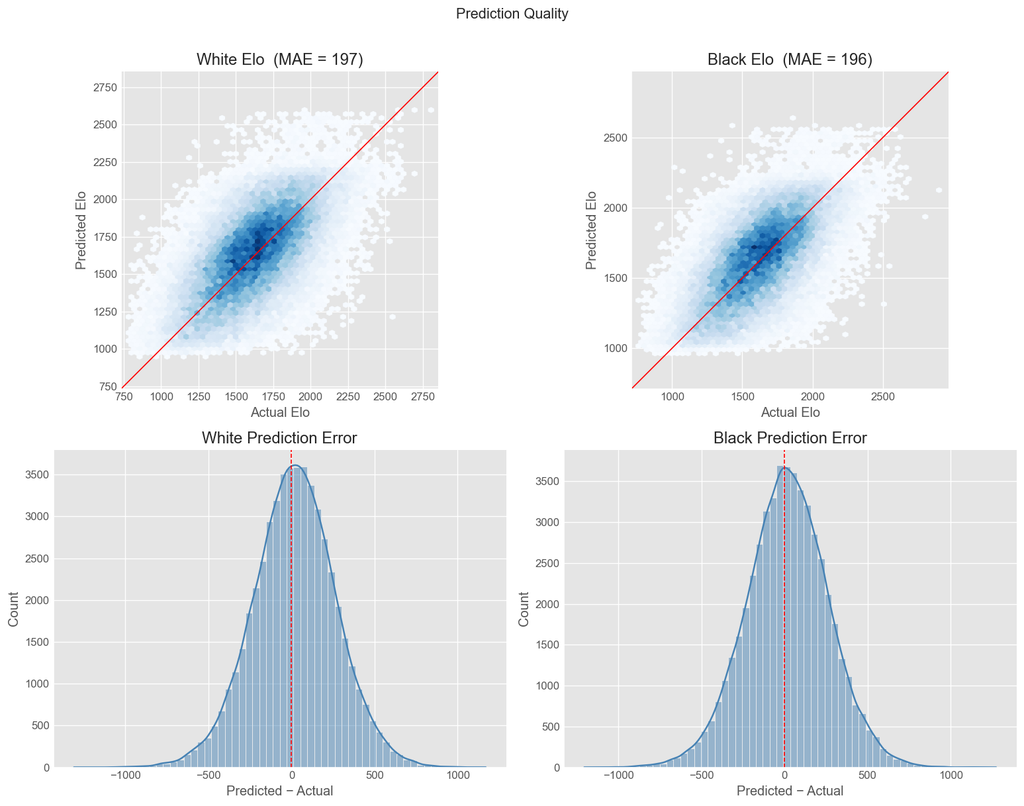

```
MAE by Elo bracket:
------------------------------------------
           (0, 1000]  MAE =   291  n = 895
        (1000, 1200]  MAE =   203  n = 5,760
        (1200, 1400]  MAE =   201  n = 16,143
        (1400, 1600]  MAE =   195  n = 26,916
        (1600, 1800]  MAE =   184  n = 28,615
        (1800, 2000]  MAE =   189  n = 18,366
        (2000, 2200]  MAE =   218  n = 6,784
        (2200, 2500]  MAE =   282  n = 1,813
        (2500, 4000]  MAE =   386  n = 108
```

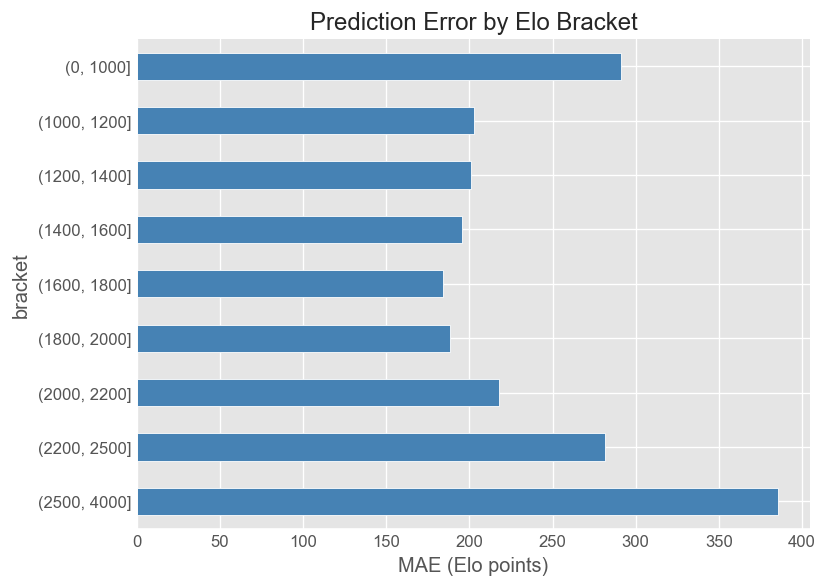

## Predicted Rating Distributions

One of the nicest things about the distribution output: instead of just getting a number, you see the full probability mass the model assigns across the rating range. A narrow peak means the model is confident; a wide spread means it's uncertain.

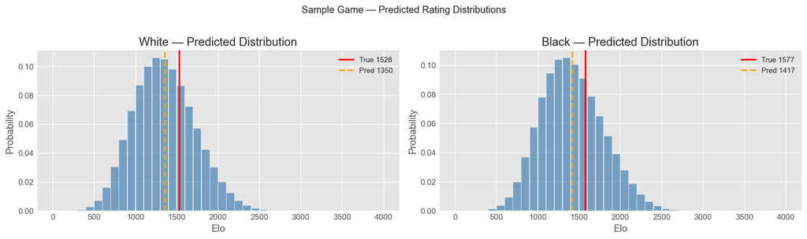

## Latent Space — t-SNE & PCA

Are games with similar Elo ratings close together in the model's internal representation?

```
Running t-SNE on 3000 vectors...
```

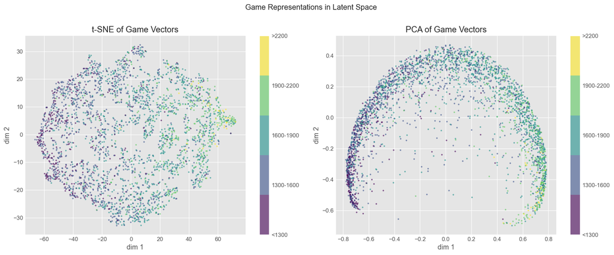

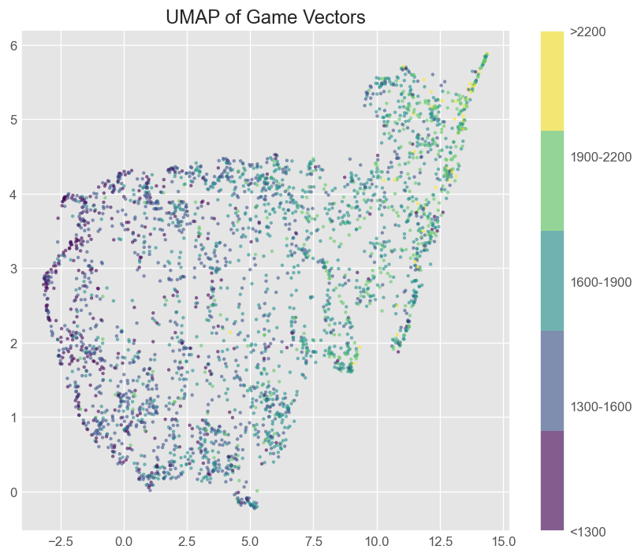

### AE Embedding Space

Same visualisation but using the raw AE embeddings before the main model sees them.

```
Running t-SNE on 3000 AE embeddings...
```

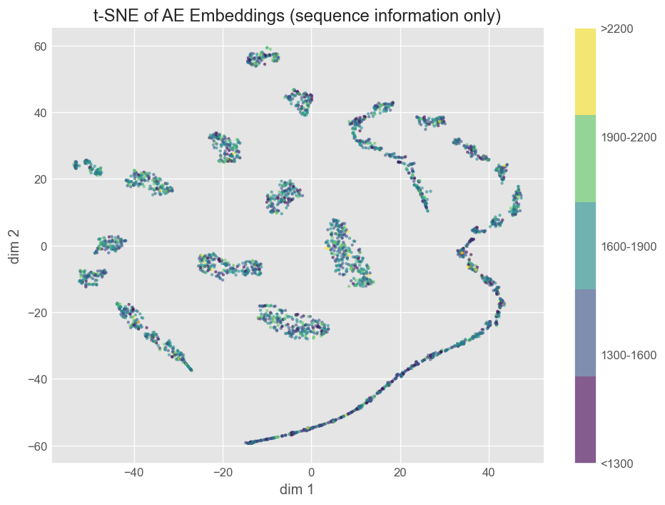

## Feature Group Importance

Zero out each feature group in turn and measure how much worse the MAE gets.

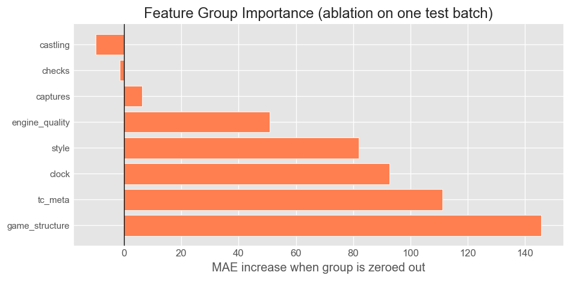

```
  game_structure      Δ = +145.6
  tc_meta             Δ = +111.0
  clock               Δ = +92.6
  style               Δ = +81.9
  engine_quality      Δ = +50.9
  captures            Δ = +6.3
  checks              Δ = -1.4
  castling            Δ = -9.8
```

## Opening Analysis (ECO codes)

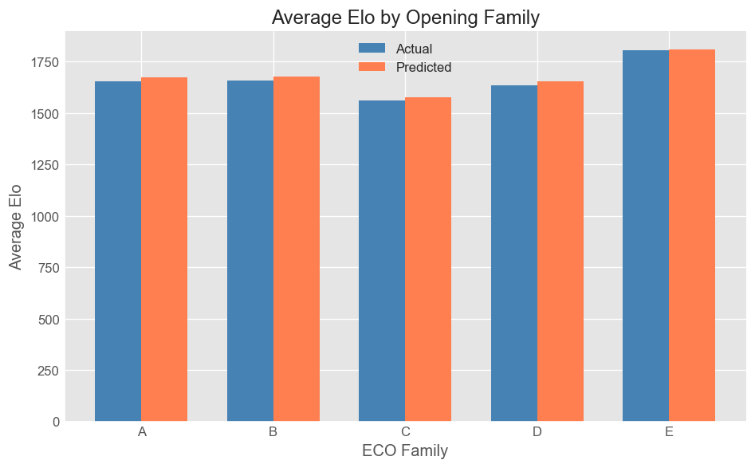

```
Top 5 highest-Elo ECO codes (min 10 games):
    E97  avg Elo: 2117  (n=12)
    B96  avg Elo: 2065  (n=10)
    E92  avg Elo: 2029  (n=12)
    A90  avg Elo: 2018  (n=10)
    E94  avg Elo: 2017  (n=13)

Bottom 5 lowest-Elo ECO codes (min 10 games):
    C20  avg Elo: 1424  (n=1838)
    C40  avg Elo: 1463  (n=1056)
    C22  avg Elo: 1468  (n=252)
    C49  avg Elo: 1475  (n=28)
    C46  avg Elo: 1485  (n=620)
```

## Anomaly Detection

Games where the model's estimate differs most from actual rating — potential over/underperformers.

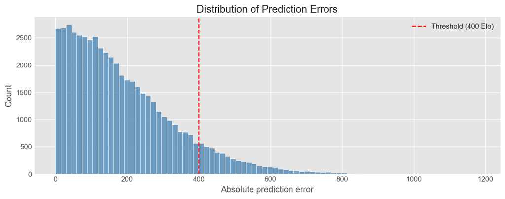

```
Flagged 5049 games with error > 400 Elo  (9.6%)

Top 15 OVERPERFORMERS  (model rates them higher than actual)
   Predicted      Actual      Diff
  --------------------------------
        2286        1104     +1182
        2563        1423     +1140
        2385        1246     +1139
        2237        1172     +1066
        2361        1328     +1033
        2447        1415     +1032
        2098        1082     +1016
        2392        1388     +1004
        2520        1545      +975
        2529        1584      +945
```

[output cut: 24 more lines]

## Single-Game Inference

Paste any PGN below and run the cell. Works with Lichess and chess.com exports. If the PGN has `[WhiteElo]` and `[BlackElo]` headers, the actual ratings are shown for comparison.

Note: this model was trained on Lichess ratings. Chess.com ratings tend to run ~100-200 points lower for the same strength player, so predictions on chess.com games may be slightly high.

[output not shown]

## Export

Press `Ctrl+S` to save the notebook, then run this cell.